# Developing Countries with Net-Zero Target

CDMMP

# Summary

The countries we study are listed below. Each link will take you to an in-depth, country level analysis.

- All
- Argentina
- Benin
- Burkina Faso
- Bangladesh
- Brazil
- Chile
- Colombia
- Costa Rica
- Dominican Republic
- Ecuador
- Ghana
- Guinea
- Indonesia
- India
- Kazakhstan
- Kyrgyzstan
- Cambodia
- Lao PDR
- Sri Lanka
- Madagascar
- Mexico
- Mozambique
- Mauritius
- Malawi
- Malaysia
- Namibia
- Nigeria
- Nicaragua
- Nepal
- Oman
- Pakistan
- Panama
- Peru
- Rwanda
- Saudi Arabia
- Senegal
- Togo
- Thailand
- Trinidad and Tobago
- Tunisia
- Turkey
- Tanzania
- Uganda
- Ukraine
- Uruguay
- Viet Nam
- South Africa
- Zambia

Our counterfactuals are split into two parts.

**Part 1**

CTF1: Setting tariffs to bilateral mean (Shapiro)

CTF2: Setting tariffs to OECD mean

CTF3: Carbon policy

CTF4: Carbon policy + CBAM

**Part 2**

CTF5: Large country coalition

CTF6: Large country coalition + developing country respond with equivalence

CTF7: Large country coalition + developing country respond without equivalence

# Part 1

## Welfare

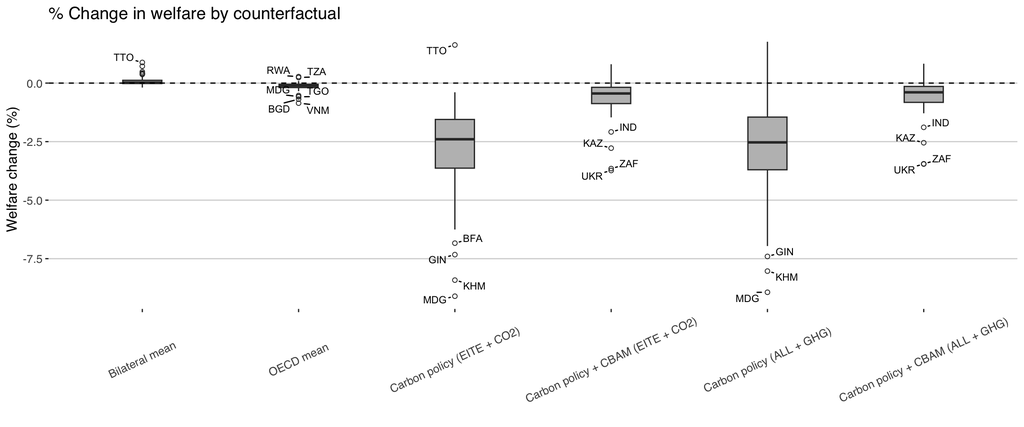

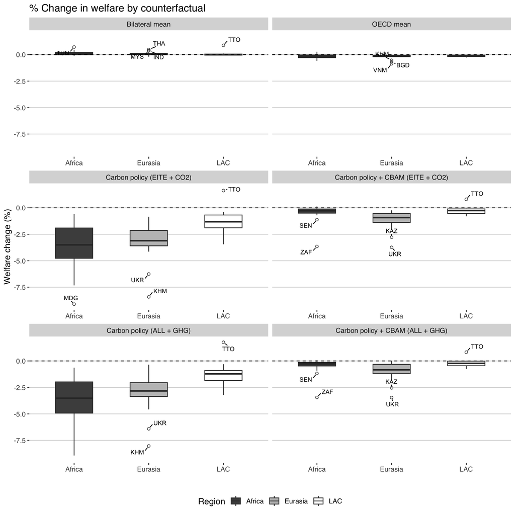

## Trade flows

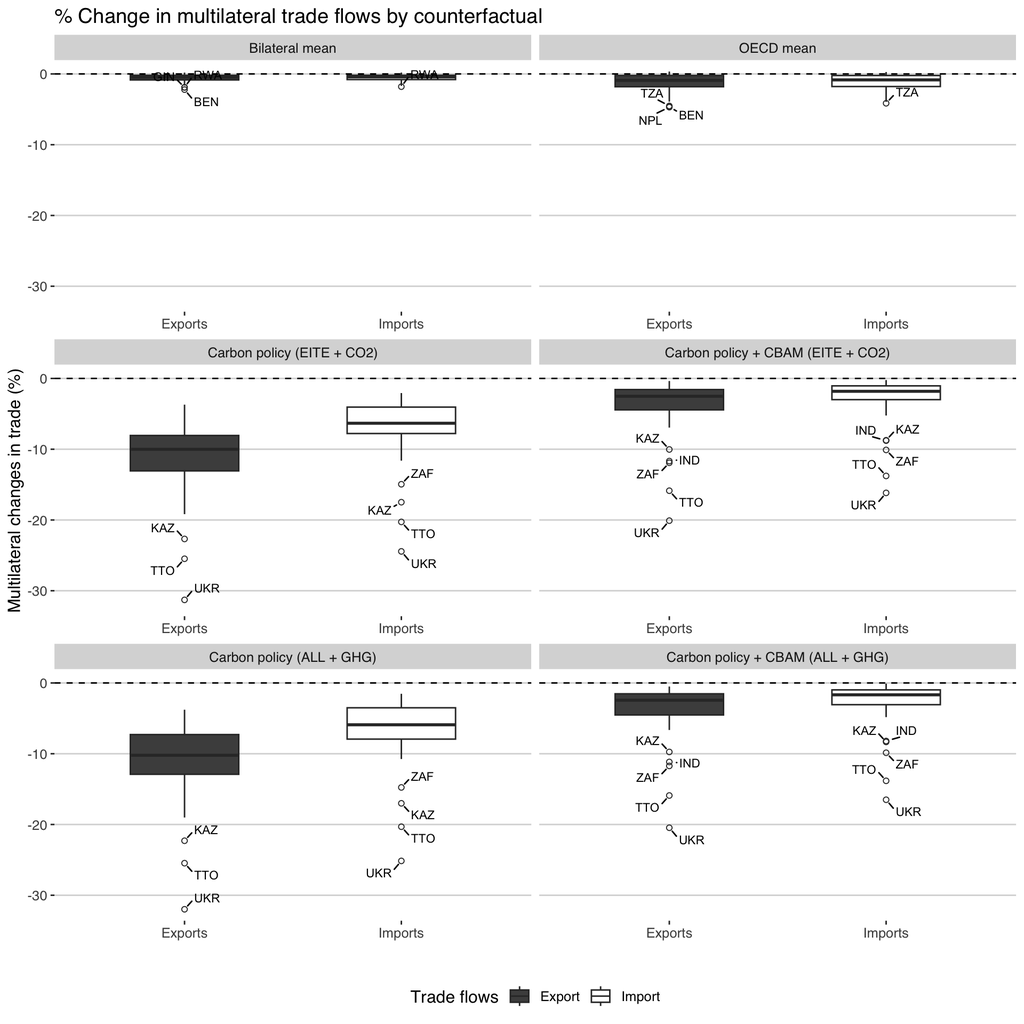

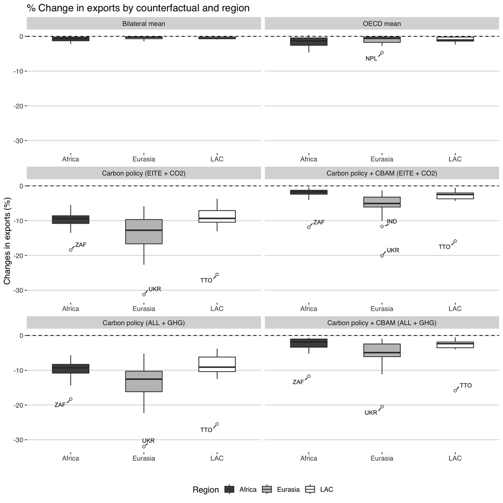

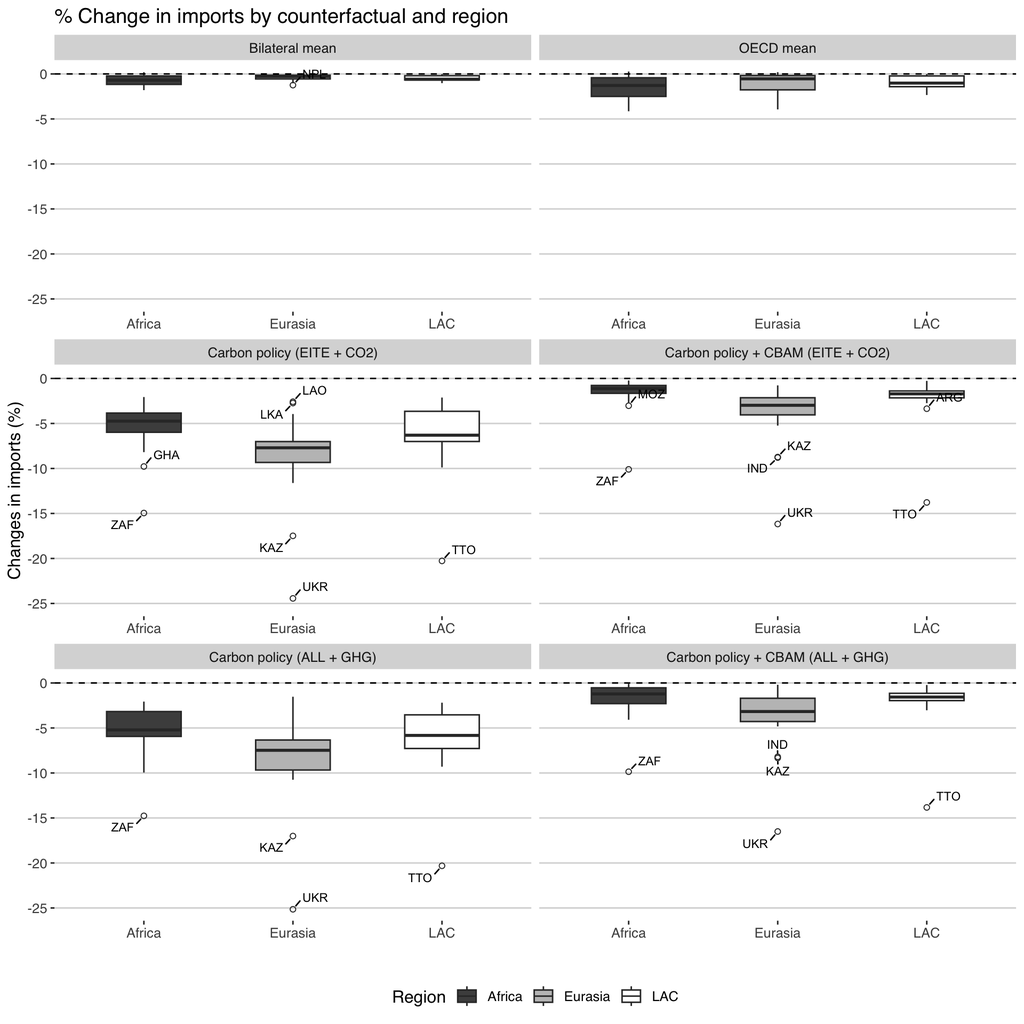

[figure not shown]

## Emissions

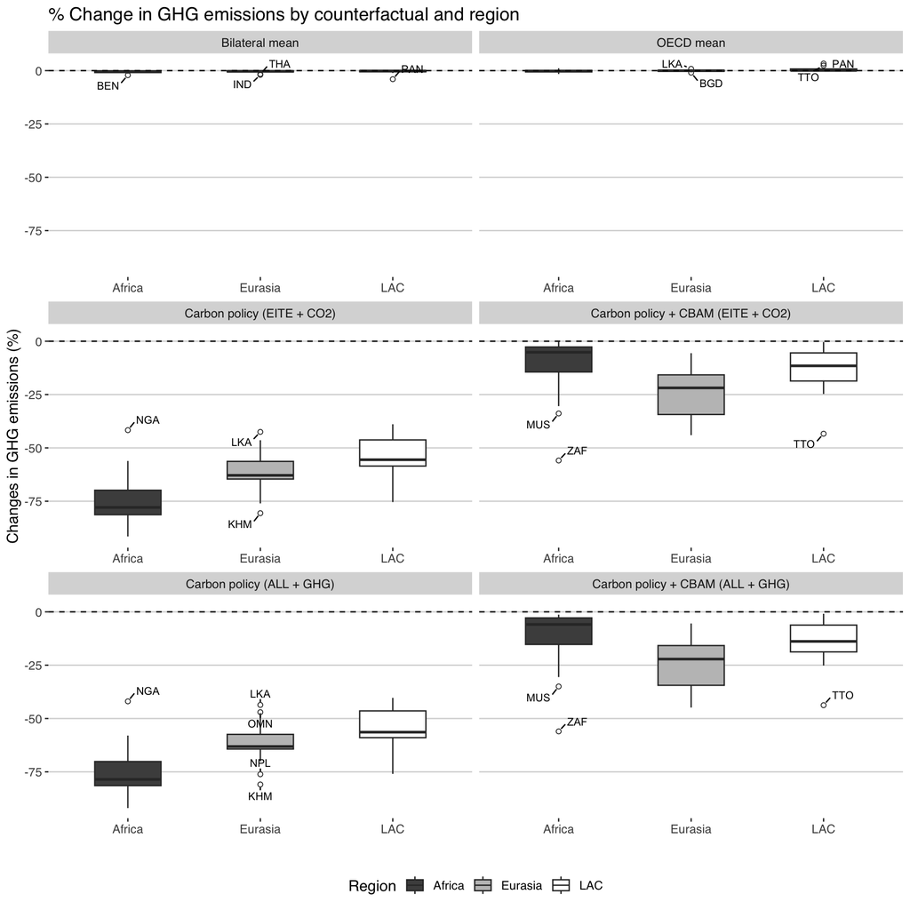

# Part 2

## Welfare

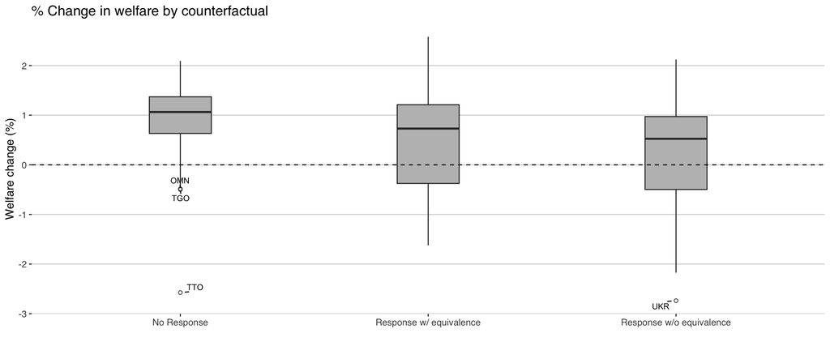

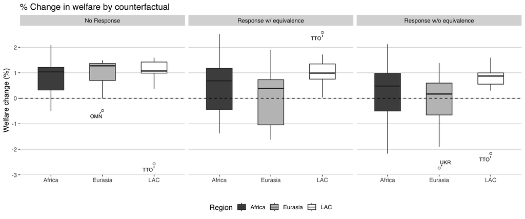

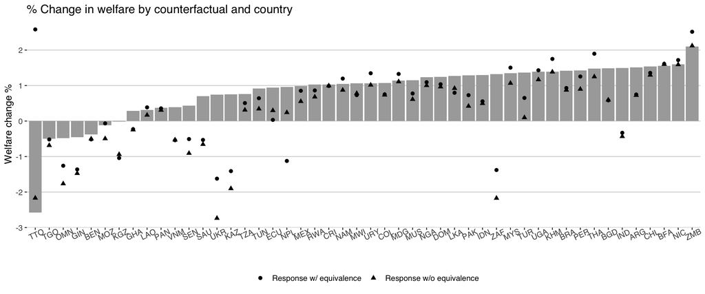

## Trade flows

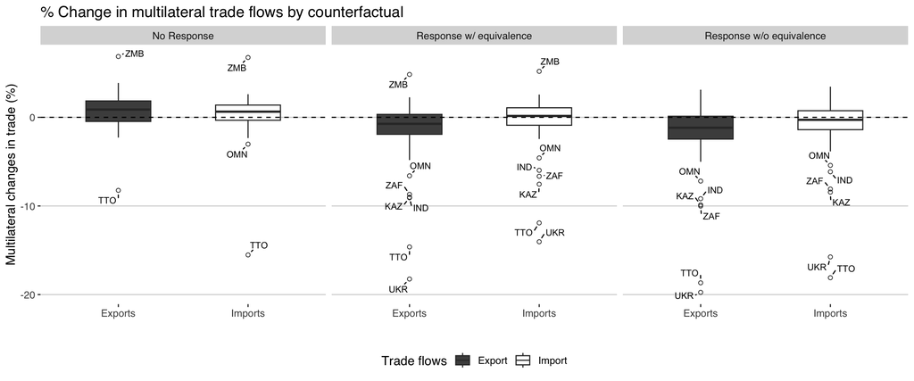

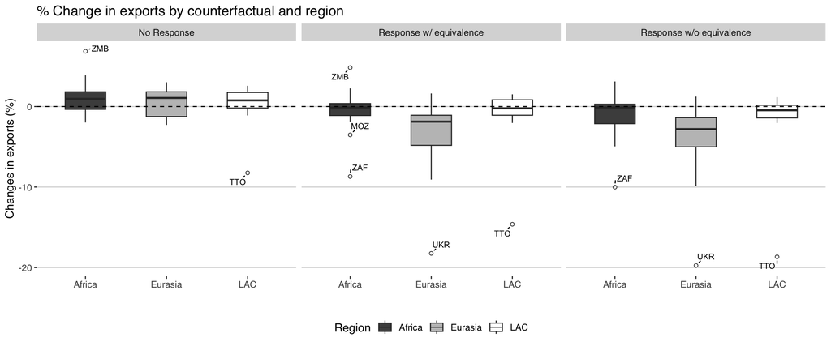

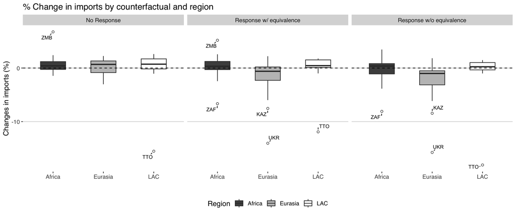

## Emissions

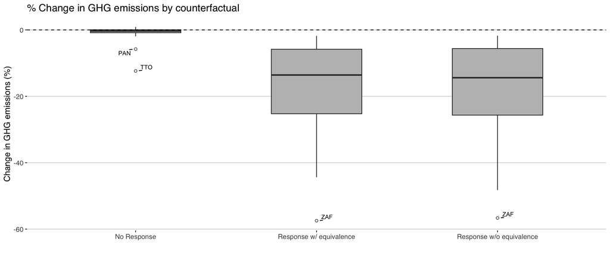

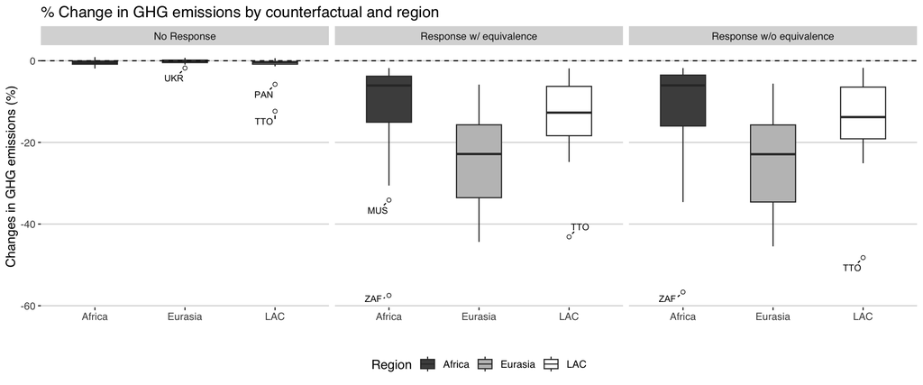